# Notes on Chapter 13 – Numbers

Norman Lim

2025-07-27

### Prerequisites

```r
library(tidyverse)
library(nycflights13)
```

## Making numbers

- parsing strings into numbers using the `readr` package:

```r
x <- c("1.2", "5.6", "1e6")

parse_double(x)
```

```
## [1] 1.2e+00 5.6e+00 1.0e+06
```

- parsing when the intended string contains non-numeric text that needs to be ignored:

```r
x <- c("$1,234", "USD 3,513", "59%")

parse_number(x)
```

```
## [1] 1234 3513   59
```

## Counts

- Using `count` for quick exploration and checks:

```r
flights |> count(dest)
```

```
## # A tibble: 105 × 2
##    dest      n
##    <chr> <int>
##  1 ABQ     254
##  2 ACK     265
##  3 ALB     439
##  4 ANC       8
##  5 ATL   17215
##  6 AUS    2439
##  7 AVL     275
##  8 BDL     443
##  9 BGR     375
## 10 BHM     297
## # ℹ 95 more rows
```

- Using `count` to see the most common values:

```r
flights |> count(dest, sort = TRUE)
```

```
## # A tibble: 105 × 2
##    dest      n
##    <chr> <int>
##  1 ORD   17283
##  2 ATL   17215
##  3 LAX   16174
##  4 BOS   15508
##  5 MCO   14082
##  6 CLT   14064
##  7 SFO   13331
##  8 FLL   12055
##  9 MIA   11728
## 10 DCA    9705
## # ℹ 95 more rows
```

- To see all the results, we can add `|> View()` or `|> print(n = Inf)`
- Doing `count()` “by hand” using `group_by()`, `summarize()`, and `n()`. (Useful if you want to compute for other summaries too.)

```r
flights |>
  group_by(dest) |>
  summarize(
    n = n(),
    delay = mean(arr_delay, na.rm = TRUE)
  )
```

```
## # A tibble: 105 × 3
##    dest      n delay
##    <chr> <int> <dbl>
##  1 ABQ     254  4.38
##  2 ACK     265  4.85
##  3 ALB     439 14.4
##  4 ANC       8 -2.5
##  5 ATL   17215 11.3
##  6 AUS    2439  6.02
##  7 AVL     275  8.00
##  8 BDL     443  7.05
##  9 BGR     375  8.03
## 10 BHM     297 16.9
## # ℹ 95 more rows
```

- Counting distinct values using `n_distinct()`:

```r
flights |>
  group_by(dest) |>
  summarize(carriers= n_distinct(carrier)) |>
  arrange(desc(carriers))
```

```
## # A tibble: 105 × 2
##    dest  carriers
##    <chr>    <int>
##  1 ATL          7
##  2 BOS          7
##  3 CLT          7
##  4 ORD          7
##  5 TPA          7
##  6 AUS          6
##  7 DCA          6
##  8 DTW          6
##  9 IAD          6
## 10 MSP          6
## # ℹ 95 more rows
```

- Getting a weighted count by summing:

```r
flights |>
  group_by(tailnum) |>
  summarize(miles = sum(distance))
```

```
## # A tibble: 4,044 × 2
##    tailnum  miles
##    <chr>    <dbl>
##  1 D942DN    3418
##  2 N0EGMQ  250866
##  3 N10156  115966
##  4 N102UW   25722
##  5 N103US   24619
##  6 N104UW   25157
##  7 N10575  150194
##  8 N105UW   23618
##  9 N107US   21677
## 10 N108UW   32070
## # ℹ 4,034 more rows
```

- Getting a weighted count using the `wt` argument to `count()`:

```r
flights |> count(tailnum, wt = distance)
```

```
## # A tibble: 4,044 × 2
##    tailnum      n
##    <chr>    <dbl>
##  1 D942DN    3418
##  2 N0EGMQ  250866
##  3 N10156  115966
##  4 N102UW   25722
##  5 N103US   24619
##  6 N104UW   25157
##  7 N10575  150194
##  8 N105UW   23618
##  9 N107US   21677
## 10 N108UW   32070
## # ℹ 4,034 more rows
```

- Counting the number of missing values by combining `sum()` and `is.na()`:

```r
flights |>
  group_by(dest) |>
  summarize(n_cancelled = sum(is.na(dep_time)))
```

```
## # A tibble: 105 × 2
##    dest  n_cancelled
##    <chr>       <int>
##  1 ABQ             0
##  2 ACK             0
##  3 ALB            20
##  4 ANC             0
##  5 ATL           317
##  6 AUS            21
##  7 AVL            12
##  8 BDL            31
##  9 BGR            15
## 10 BHM            25
## # ℹ 95 more rows
```

### Exercises

1. How can you use `count()` to count the number of rows with a missing value for a given variable?

Ans. Combine `count()` with `is.na()`.

```r
flights |>
  count(is.na(dep_time)) |>
  rename(
    is_na = `is.na(dep_time)`,
    count = n
  ) |>
  mutate(is_na = if_else(is_na == FALSE, "not missing", "missing"))
```

```
## # A tibble: 2 × 2
##   is_na        count
##   <chr>        <int>
## 1 not missing 328521
## 2 missing       8255
```

2. Expand the following calls to `count()` to instead use `group_by()` `summarize()`, and `arrange()`:
> 1. `flights |> count(dest, sort = TRUE`)
> 2. `flights |> count(tailnum, wt = distance`

Ans.

for No. 1

```r
flights |>
  group_by(dest) |>
  summarize(
    n = n()
  ) |>
  arrange(desc(n))
```

```
## # A tibble: 105 × 2
##    dest      n
##    <chr> <int>
##  1 ORD   17283
##  2 ATL   17215
##  3 LAX   16174
##  4 BOS   15508
##  5 MCO   14082
##  6 CLT   14064
##  7 SFO   13331
##  8 FLL   12055
##  9 MIA   11728
## 10 DCA    9705
## # ℹ 95 more rows
```

for No. 2

```r
flights |>
  group_by(tailnum) |>
  summarize(miles = sum(distance))
```

```
## # A tibble: 4,044 × 2
##    tailnum  miles
##    <chr>    <dbl>
##  1 D942DN    3418
##  2 N0EGMQ  250866
##  3 N10156  115966
##  4 N102UW   25722
##  5 N103US   24619
##  6 N104UW   25157
##  7 N10575  150194
##  8 N105UW   23618
##  9 N107US   21677
## 10 N108UW   32070
## # ℹ 4,034 more rows
```

### Arithmetic and recycling rules

- When the vector lengths are mismatched, the elements of the shorter vector is *recycled* or repeated:

```r
x <- c(1, 2, 10, 20)
x / 5
```

```
## [1] 0.2 0.4 2.0 4.0
```

```r
x / c(5, 5, 5, 5)
```

```
## [1] 0.2 0.4 2.0 4.0
```

- R throws a warning when the length of the longer vector is not a multiple of the length of the shorter vector:

```r
x * c(1, 2)
```

```
## [1]  1  4 10 40
```

```r
x * c(1, 2, 3)
```

```
## Warning in x * c(1, 2, 3): longer object length is not a multiple of shorter
## object length
```

```
## [1]  1  4 30 20
```

- Recycling rules are also applied to logical comparisons.

### Minimum and Maximum

- The functions `pmin()` and `pmax()` return the smallest or largest value in each row:

```r
df <- tribble(
  ~x, ~y,
  1, 3,
  5, 2,
  7, NA
)

df |>
  mutate(
    min = pmin(x, y, na.rm = TRUE),
    max = pmax(x, y, na.rm = TRUE)
  )
```

```
## # A tibble: 3 × 4
##       x     y   min   max
##   <dbl> <dbl> <dbl> <dbl>
## 1     1     3     1     3
## 2     5     2     2     5
## 3     7    NA     7     7
```

### Modular arithmetic

- The function `%/%` gives the integer part of the quotient and `%%` gives the remainder:

```r
1:10 %/% 3
```

```
##  [1] 0 0 1 1 1 2 2 2 3 3
```

```r
1:10 %% 3
```

```
##  [1] 1 2 0 1 2 0 1 2 0 1
```

- Modular arithmetic is handy for unpacking time into `hour` and `minute`:

```r
flights |>
  mutate(
    hour = sched_dep_time %/% 100,
    minute = sched_dep_time %% 100,
    .keep = "used"
  )
```

```
## # A tibble: 336,776 × 3
##    sched_dep_time  hour minute
##             <int> <dbl>  <dbl>
##  1            515     5     15
##  2            529     5     29
##  3            540     5     40
##  4            545     5     45
##  5            600     6      0
##  6            558     5     58
##  7            600     6      0
##  8            600     6      0
##  9            600     6      0
## 10            600     6      0
## # ℹ 336,766 more rows
```

- From section 12, we learned to determine the proportion of TRUE values to FALSE values in a logical vector by using `mean()`.
- Combining this with modular arithmetic, we can plot the proportion of cancelled flights against the hour:

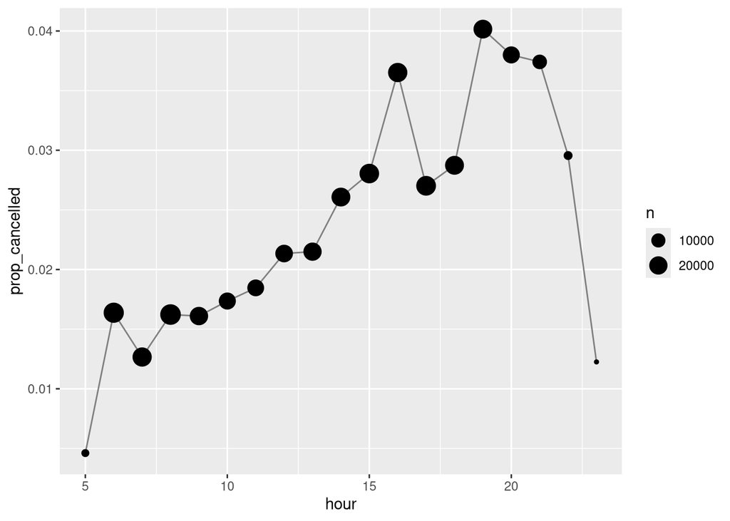

```r
flights |>
  group_by(hour = sched_dep_time %/% 100) |>
  summarize(
    prop_cancelled = mean(is.na(dep_time)),
    n = n()
  ) |>
  filter(hour > 1) |>
  ggplot(aes(x = hour, y = prop_cancelled)) +
  geom_line(color = "grey50") +
  geom_point(aes(size = n))
```

This is a condensed version of the code below:

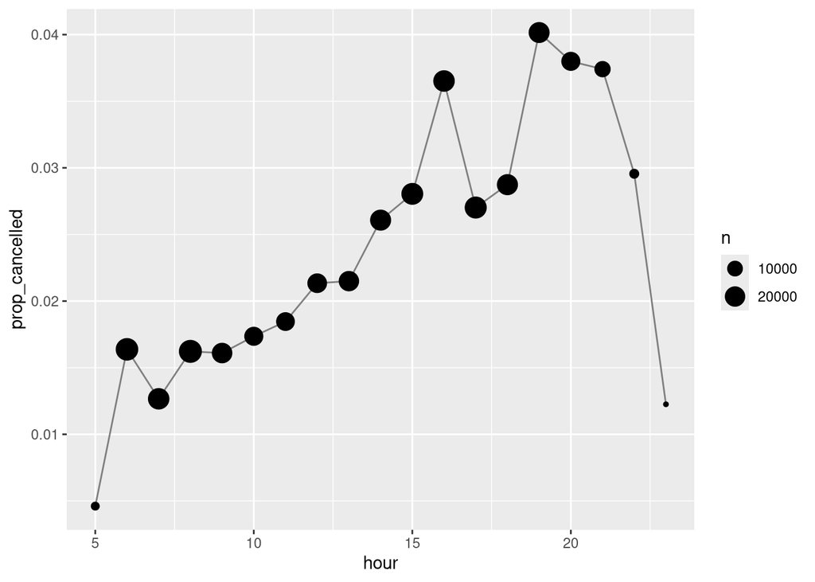

```r
flights |>
  mutate(hour = sched_dep_time %/% 100) |>
  group_by(hour) |>
  summarize(
    prop_cancelled = mean(is.na(dep_time)),
    n = n()
  ) |>
  filter(hour > 1) |>
  ggplot(aes(x = hour, y = prop_cancelled)) +
  geom_line(color = "grey50") +
  geom_point(aes(size = n))
```

### Logarithms

- Useful for dealing with data that ranges across multiple orders of magnitude.
- `log2()` and `log10()` are generally easier to interpret than logs of other bases.
- In base 2, every one step “forward” corresponds to doubling on the original scale, and every step “backward” corresponds to halving – think of the f-stops in photography.

### Rounding

- Rounding to the nearest integer:

```r
round(123.456)
```

```
## [1] 123
```

- Changing the precision of rounding using the `digits` argument:

```r
round(123.456, digits = 2)  # two digits to the right of decimal point
```

```
## [1] 123.46
```

```r
round(123.456, 1)           # one digit...
```

```
## [1] 123.5
```

```r
round(123.456, -1)          # nearest ten
```

```
## [1] 120
```

```r
round(123.456, -2)          # nearest hundred
```

```
## [1] 100
```

- R uses a rounding scheme called “Banker’s rounding” – a number halfway between two integers will be rounded to the even integer.

```r
round(c(1.5, 2.5))
```

```
## [1] 2 2
```

- Because of this rounding scheme, we need to use `floor()` or `ceiling()` if we want to specifically round up or round down:

```r
x <- 123.456

floor(x)
```

```
## [1] 123
```

```r
ceiling(x)
```

```
## [1] 124
```

- Since `floor()` and `ceiling()` don’t have a `digits` argument, here’s a trick you can use to control the number of digits used in rounding:

```r
# Round down to the nearest two digits
floor(x / 0.01) * 0.01
```

```
## [1] 123.45
```

```r
# Round up to the nearest two digits
ceiling(x / 0.01) * 0.01
```

```
## [1] 123.46
```

### Cutting numbers into ranges

- Using `cut()` to break up a numeric vector into discrete buckets or bins:

```r
x <- c(1, 2, 5, 10, 15, 20)

# With even spacing
cut(x, breaks = c(0, 5, 10, 15, 20))
```

```
## [1] (0,5]   (0,5]   (0,5]   (5,10]  (10,15] (15,20]
## Levels: (0,5] (5,10] (10,15] (15,20]
```

```r
# With uneven spacing
cut(x, breaks = c(0, 5, 10, 100))
```

```
## [1] (0,5]    (0,5]    (0,5]    (5,10]   (10,100] (10,100]
## Levels: (0,5] (5,10] (10,100]
```

```r
# breeaks with custom labels
cut(x,
  breaks = c(0, 5, 10, 15, 20),
  labels = c("small", "medium", "large", "extra_large")
)
```

```
## [1] small       small       small       medium      large       extra_large
## Levels: small medium large extra_large
```

- Any values outside the range of `breaks` will become `NA`

```r
y <- c(NA, -10, 5, 10, 30)
cut(y, breaks = c(0, 5, 10, 15, 20))
```

```
## [1] <NA>   <NA>   (0,5]  (5,10] <NA>
## Levels: (0,5] (5,10] (10,15] (15,20]
```

### Cummulative and rolling aggregates

- Base R provides functions that start with `cum`:

```r
x <- 1:10
cumsum(x)
```

```
##  [1]  1  3  6 10 15 21 28 36 45 55
```

```r
s <- 1:100
cumsum(s)
```

```
##   [1]    1    3    6   10   15   21   28   36   45   55   66   78   91  105  120
##  [16]  136  153  171  190  210  231  253  276  300  325  351  378  406  435  465
##  [31]  496  528  561  595  630  666  703  741  780  820  861  903  946  990 1035
##  [46] 1081 1128 1176 1225 1275 1326 1378 1431 1485 1540 1596 1653 1711 1770 1830
##  [61] 1891 1953 2016 2080 2145 2211 2278 2346 2415 2485 2556 2628 2701 2775 2850
##  [76] 2926 3003 3081 3160 3240 3321 3403 3486 3570 3655 3741 3828 3916 4005 4095
##  [91] 4186 4278 4371 4465 4560 4656 4753 4851 4950 5050
```

This will make Gauss smile for sure.

- More functions for rolling or sliding aggregates are available in the `slider` package.

### Exercises

3. Currently `dep_time` and `sched_time` are convenient to look at, but hard to compute with because they’re not really continuous numbers. You can see the basic problem by running the code below: there’s a gap between each hour.

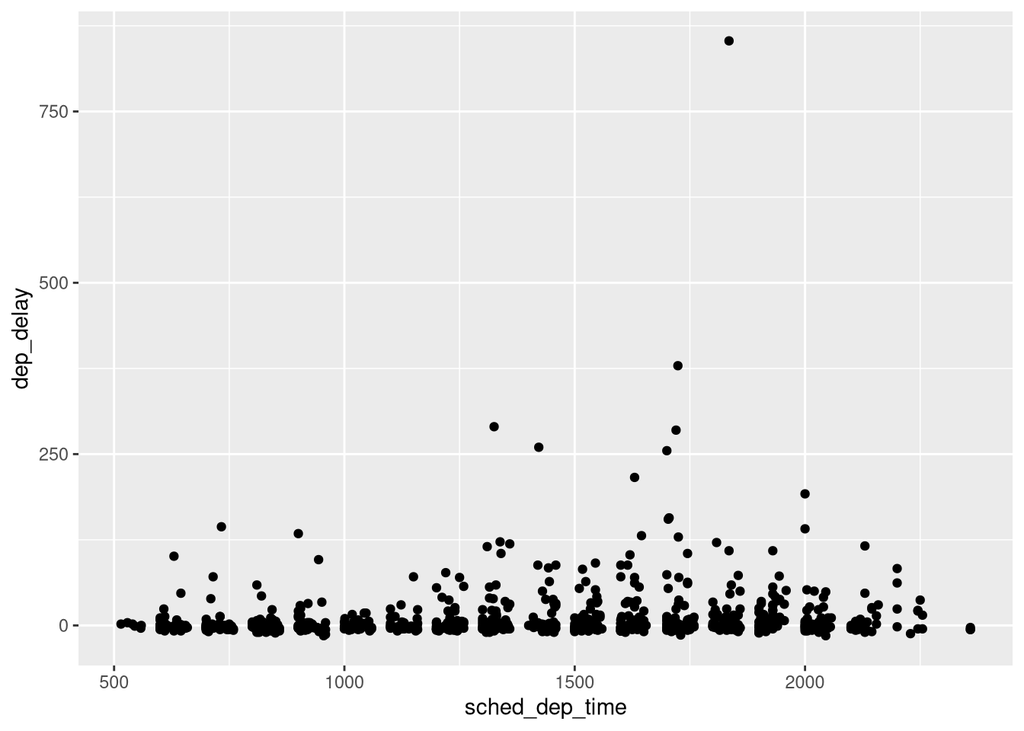

```r
flights |>
  filter(month == 1, day == 1) |>
  ggplot(aes(x = sched_dep_time, y = dep_delay)) +
  geom_point()
```

Convert them to a more truthful representation of time (either fractional hours or minutes since midnight).

Ans.

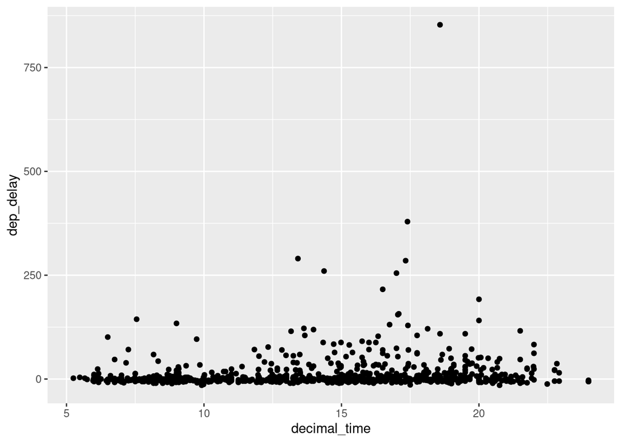

```r
flights |>
  mutate(
    hour = sched_dep_time %/% 100,
    minute = sched_dep_time %% 100,
    decimal_time = hour + minute / 60
  ) |>
  filter(month == 1, day == 1) |>
  ggplot(aes(x = decimal_time, y = dep_delay)) +
  geom_point()
```

4. Round `dep_time` and `arr_time` to the nearest five minutes.

Ans.

```r
flights |>
  mutate(
    dep_hour = dep_time %/% 100,
    dep_minute = sched_dep_time %% 100,
    dep_minute = round(dep_minute / 5) * 5,
    dep_hour = if_else(dep_minute == 60, dep_hour + 1, dep_hour),
    dep_minute = if_else(dep_minute == 60, 0, dep_minute),
    .after = dep_time
  )
```

```
## # A tibble: 336,776 × 21
##     year month   day dep_time dep_hour dep_minute sched_dep_time dep_delay
##    <int> <int> <int>    <int>    <dbl>      <dbl>          <int>     <dbl>
##  1  2013     1     1      517        5         15            515         2
##  2  2013     1     1      533        5         30            529         4
##  3  2013     1     1      542        5         40            540         2
##  4  2013     1     1      544        5         45            545        -1
##  5  2013     1     1      554        5          0            600        -6
##  6  2013     1     1      554        6          0            558        -4
##  7  2013     1     1      555        5          0            600        -5
##  8  2013     1     1      557        5          0            600        -3
##  9  2013     1     1      557        5          0            600        -3
## 10  2013     1     1      558        5          0            600        -2
## # ℹ 336,766 more rows
## # ℹ 13 more variables: arr_time <int>, sched_arr_time <int>, arr_delay <dbl>,
## #   carrier <chr>, flight <int>, tailnum <chr>, origin <chr>, dest <chr>,
## #   air_time <dbl>, distance <dbl>, hour <dbl>, minute <dbl>, time_hour <dttm>
```

```r
# Similar approach for arr_time.
```

## General transformations

### Ranks

- `min_rank()` uses the typical method for dealing with ties:

```r
x <- c(1, 2, 2, 3, 4, NA)
min_rank(x)
```

```
## [1]  1  2  2  4  5 NA
```

- Using `desc()` to rank from highest to lowest:

```r
min_rank(desc(x))
```

```
## [1]  5  3  3  2  1 NA
```

- Examples of other ranking functions:

```r
df <- tibble(x = x)
df |>
  mutate(
    row_number = row_number(x),
    dense_rank = dense_rank(x),
    percent_rank = percent_rank(x),
    cume_dist = cume_dist(x)
  )
```

```
## # A tibble: 6 × 5
##       x row_number dense_rank percent_rank cume_dist
##   <dbl>      <int>      <int>        <dbl>     <dbl>
## 1     1          1          1         0          0.2
## 2     2          2          2         0.25       0.6
## 3     2          3          2         0.25       0.6
## 4     3          4          3         0.75       0.8
## 5     4          5          4         1          1
## 6    NA         NA         NA        NA         NA
```

Important arguments for `rank()` functions: - `ties.method`: for breaking ties - `na.last = "keep:`: to keep `NA`s as `NA`

- `row_number()`, when used without any arguments will give the “current” row.
- We can take advantage of this when we need to divide data into similarly sized groups:

```r
df <- tibble(id = 1:10)

df |>
  mutate(
    row0 = row_number() - 1,
    three_groups = row0 %% 3,
    three_in_each_group = row0 %/% 3
  )
```

```
## # A tibble: 10 × 4
##       id  row0 three_groups three_in_each_group
##    <int> <dbl>        <dbl>               <dbl>
##  1     1     0            0                   0
##  2     2     1            1                   0
##  3     3     2            2                   0
##  4     4     3            0                   1
##  5     5     4            1                   1
##  6     6     5            2                   1
##  7     7     6            0                   2
##  8     8     7            1                   2
##  9     9     8            2                   2
## 10    10     9            0                   3
```

### Offsets

- Using `lead()` and `lag()`:

```r
x <- c(2, 5, 11, 11, 19, 35)

lag(x)
```

```
## [1] NA  2  5 11 11 19
```

```r
lead(x)
```

```
## [1]  5 11 11 19 35 NA
```

Clever uses for `lag()`:

```r
# Get the difference between current and previous value
x - lag(x)
```

```
## [1] NA  3  6  0  8 16
```

```r
# Determine if the current value changes
x == lag(x)
```

```
## [1]    NA FALSE FALSE  TRUE FALSE FALSE
```

### Consecutive identifiers

- Useful when we want the items to be in a different category after crossing a certain threshold.
- Example: A situation where a new session should becin after a gap of more than x minutes since last activity:

```r
events <- tibble(
  time = c(0, 1, 2, 3, 5, 10, 12, 15, 17, 19, 20, 27, 28, 30)
)

events <- events |>
  mutate(
    diff = time - lag(time, default = first(time)),
    has_gap = diff >= 5
  )

events
```

```
## # A tibble: 14 × 3
##     time  diff has_gap
##    <dbl> <dbl> <lgl>
##  1     0     0 FALSE
##  2     1     1 FALSE
##  3     2     1 FALSE
##  4     3     1 FALSE
##  5     5     2 FALSE
##  6    10     5 TRUE
##  7    12     2 FALSE
##  8    15     3 FALSE
##  9    17     2 FALSE
## 10    19     2 FALSE
## 11    20     1 FALSE
## 12    27     7 TRUE
## 13    28     1 FALSE
## 14    30     2 FALSE
```

- Example: Similar situation as before, but we want to get numeric results so that we can apply other functions:

```r
events |> mutate(
  group = cumsum(has_gap)
)
```

```
## # A tibble: 14 × 4
##     time  diff has_gap group
##    <dbl> <dbl> <lgl>   <int>
##  1     0     0 FALSE       0
##  2     1     1 FALSE       0
##  3     2     1 FALSE       0
##  4     3     1 FALSE       0
##  5     5     2 FALSE       0
##  6    10     5 TRUE        1
##  7    12     2 FALSE       1
##  8    15     3 FALSE       1
##  9    17     2 FALSE       1
## 10    19     2 FALSE       1
## 11    20     1 FALSE       1
## 12    27     7 TRUE        2
## 13    28     1 FALSE       2
## 14    30     2 FALSE       2
```

- Example: Create a new grouping every time one of its arguments changes using `consecutive_id()` and `slice_head()`:

```r
df <- tibble(
  x = c("a", "a", "a", "b", "c", "c", "d", "e", "a", "a", "b", "b"),
  y = c(1, 2, 3, 2, 4, 1, 3, 9, 4, 8, 10, 199)
)

df |>
  group_by(id = consecutive_id(x)) |>
  slice_head(n = 1)
```

```
## # A tibble: 7 × 3
## # Groups:   id [7]
##   x         y    id
##   <chr> <dbl> <int>
## 1 a         1     1
## 2 b         2     2
## 3 c         4     3
## 4 d         3     4
## 5 e         9     5
## 6 a         4     6
## 7 b        10     7
```

## Exercises

1. Find the 10 most delayed flights using a ranking function.
2. Which plane (`tailnum`) has the worst on-time record?
3. What time of day should you fly if you want to avoid delays as much as possible?
4. What does the code do?

```r
flights |>
  group_by(dest) |>
  filter(row_number() < 4)
```

```
## # A tibble: 311 × 19
## # Groups:   dest [105]
##     year month   day dep_time sched_dep_time dep_delay arr_time sched_arr_time
##    <int> <int> <int>    <int>          <int>     <dbl>    <int>          <int>
##  1  2013     1     1      517            515         2      830            819
##  2  2013     1     1      533            529         4      850            830
##  3  2013     1     1      542            540         2      923            850
##  4  2013     1     1      544            545        -1     1004           1022
##  5  2013     1     1      554            600        -6      812            837
##  6  2013     1     1      554            558        -4      740            728
##  7  2013     1     1      555            600        -5      913            854
##  8  2013     1     1      557            600        -3      709            723
##  9  2013     1     1      557            600        -3      838            846
## 10  2013     1     1      558            600        -2      753            745
## # ℹ 301 more rows
## # ℹ 11 more variables: arr_delay <dbl>, carrier <chr>, flight <int>,
## #   tailnum <chr>, origin <chr>, dest <chr>, air_time <dbl>, distance <dbl>,
## #   hour <dbl>, minute <dbl>, time_hour <dttm>
```

Ans. It returns only the first three rows of each group created by `group_by(dest)`. Approximately equal to 105 groups x 3.

What does this code do?

```r
flights |>
  group_by(dest) |>
  filter(row_number(dep_delay) < 4)
```

```
## # A tibble: 310 × 19
## # Groups:   dest [104]
##     year month   day dep_time sched_dep_time dep_delay arr_time sched_arr_time
##    <int> <int> <int>    <int>          <int>     <dbl>    <int>          <int>
##  1  2013     1     1      848            851        -3     1155           1136
##  2  2013     1     1      946            959       -13     1146           1202
##  3  2013     1     4     2140           2159       -19     2241           2316
##  4  2013     1     5      859            901        -2     1144           1201
##  5  2013     1     5     2143           2159       -16     2257           2315
##  6  2013     1     7     1801           1810        -9     2116           2142
##  7  2013     1     7     2013           2030       -17     2150           2206
##  8  2013     1     8      735            750       -15      912            940
##  9  2013     1     9     1847           1858       -11     2024           2055
## 10  2013     1    10      810            827       -17      955           1031
## # ℹ 300 more rows
## # ℹ 11 more variables: arr_delay <dbl>, carrier <chr>, flight <int>,
## #   tailnum <chr>, origin <chr>, dest <chr>, air_time <dbl>, distance <dbl>,
## #   hour <dbl>, minute <dbl>, time_hour <dttm>
```

Ans. It returns only the first three rows of `dep_delay` for each group created by `group_by(dest)`.

5. For each destination, compute the total minutes of delay. For each flight, compute the proportion of the total delay for its destination.

Ans.

Total minutes of delay for each destination:

```r
flights |>
  filter(arr_delay > 0) |>
  group_by(dest) |>
  summarize(
    total_arr_delay = sum(arr_delay, na.rm = TRUE)
  )
```

```
## # A tibble: 103 × 2
##    dest  total_arr_delay
##    <chr>           <dbl>
##  1 ABQ              4487
##  2 ACK              2974
##  3 ALB              9580
##  4 ANC                62
##  5 ATL            300299
##  6 AUS             39940
##  7 AVL              3671
##  8 BDL              6953
##  9 BGR              6940
## 10 BHM              7267
## # ℹ 93 more rows
```

Proportion of total delay per destination for each flight:

```r
flights |>
  filter(arr_delay > 0) |>
  group_by(tailnum, dest) |>
  summarize(
    ave_prop_arr_delay = mean(arr_delay / sum(arr_delay)),
    .groups = "drop"
  )
```

```
## # A tibble: 34,458 × 3
##    tailnum dest  ave_prop_arr_delay
##    <chr>   <chr>              <dbl>
##  1 D942DN  ATL               1
##  2 D942DN  MCO               0.5
##  3 N0EGMQ  ATL               0.0417
##  4 N0EGMQ  BNA               0.0476
##  5 N0EGMQ  CLE               0.167
##  6 N0EGMQ  CLT               0.0370
##  7 N0EGMQ  CMH               0.125
##  8 N0EGMQ  DCA               0.143
##  9 N0EGMQ  DTW               0.25
## 10 N0EGMQ  MSP               0.05
## # ℹ 34,448 more rows
```

6. Delays are typically temporally correlated: even once the problem that caused the initial delay has been resolved, later flights are delayed to allow earlier flights to leave. Using `lag()`, explore how the average flight delay for an hour is related to the average delay for the previous hour.

```r
flights |>
  mutate(hour = dep_time %/% 100) |>
  group_by(year, month, day, hour) |>
  summarize(
    dep_delay = mean(dep_delay, na.rm = TRUE),
    n = n(),
    .groups = "drop"
  ) |>
  mutate(lag = dep_delay - lag(dep_delay))
```

```
## # A tibble: 7,996 × 7
##     year month   day  hour dep_delay     n    lag
##    <int> <int> <int> <dbl>     <dbl> <int>  <dbl>
##  1  2013     1     1     5    -1.53     17 NA
##  2  2013     1     1     6    -1.16     51  0.373
##  3  2013     1     1     7     1.38     37  2.54
##  4  2013     1     1     8    14.1      64 12.7
##  5  2013     1     1     9     6.02     52 -8.09
##  6  2013     1     1    10     0.513    39 -5.51
##  7  2013     1     1    11     4.98     45  4.46
##  8  2013     1     1    12     2.14     43 -2.84
##  9  2013     1     1    13     9.17     47  7.03
## 10  2013     1     1    14     4.32     50 -4.85
## # ℹ 7,986 more rows
```

7. Look at each destination. Can you find flights that are suspiciously fast (i.e. flights that represent a potential data entry error)? Compute the air time of a flight relative to the shortest flight to that destination. Which flights were most delayed in the air?

Ans. Based on speed

```r
flights |>
  mutate(
    speed = distance / (air_time / 60)
  ) |>
  select(carrier, flight, dest, air_time, distance, speed) |>
  arrange(desc(speed))
```

```
## # A tibble: 336,776 × 6
##    carrier flight dest  air_time distance speed
##    <chr>    <int> <chr>    <dbl>    <dbl> <dbl>
##  1 DL        1499 ATL         65      762  703.
##  2 EV        4667 MSP         93     1008  650.
##  3 EV        4292 GSP         55      594  648
##  4 EV        3805 BNA         70      748  641.
##  5 DL        1902 PBI        105     1035  591.
##  6 DL         315 SJU        170     1598  564
##  7 B6         707 SJU        172     1598  557.
##  8 AA         936 STT        175     1623  556.
##  9 DL         347 SJU        173     1598  554.
## 10 B6        1503 SJU        173     1598  554.
## # ℹ 336,766 more rows
```

Since the ave. speed of commercial airlines, is usually between 500 to 600 mph, flights that are suspiciously fast or suspiciously slow can be flagged.

We can also do this by getting the standard deviation of `air_time`. Flights whose air time exceed the standard deviation by a certain threshold can be flagged.

Data entry checking based on air time of flight relative to the shortest flight:

```r
# Showing the top n flights which took longer than the shortest air time
flights |>
  select(carrier, flight, dest, air_time, distance) |>
  group_by(flight, dest) |>
  mutate(
    shortest_air_time = if_else(air_time == min(air_time), air_time, min(air_time)),
    prop_to_shortest = air_time / shortest_air_time,
  ) |>
  arrange(desc(prop_to_shortest)) |>
  head(10)
```

```
## # A tibble: 10 × 7
## # Groups:   flight, dest [10]
##    carrier flight dest  air_time distance shortest_air_time prop_to_shortest
##    <chr>    <int> <chr>    <dbl>    <dbl>             <dbl>            <dbl>
##  1 B6        1491 ACK        141      199                35             4.03
##  2 AA        1750 BOS         96      187                32             3
##  3 UA        1248 BOS         92      200                32             2.88
##  4 UA         541 BOS         81      200                33             2.45
##  5 DL        1164 BOS         73      187                30             2.43
##  6 EV        4304 IAD         88      212                37             2.38
##  7 US        1860 PHL         75       96                32             2.34
##  8 UA        1240 BOS         82      200                35             2.34
##  9 B6        1012 BOS         77      187                33             2.33
## 10 UA         321 BOS         71      200                32             2.22
```

8. Find all destinations that are flown by at least two carriers. Use those destinations to come up with a relative ranking of carriers based on their performance for the same destination.

Ans.

```r
# ranking carriers based on least amount of delays
flights |>
  select(carrier, dest, dep_delay) |>
  group_by(dest, carrier) |>
  mutate(
    n = n()
  ) |>
  filter(n >= 2) |>
  summarize(
    ave_dep_delay = mean(dep_delay, na.rm = TRUE)
  ) |>
  mutate(
    ranking = rank(ave_dep_delay)
  ) |>
  arrange(dest,ranking) |>
  # show the top 4 per destination
  filter(row_number() < 5)
```

```
## # A tibble: 262 × 4
## # Groups:   dest [103]
##    dest  carrier ave_dep_delay ranking
##    <chr> <chr>           <dbl>   <dbl>
##  1 ABQ   B6             13.7         1
##  2 ACK   B6              6.46        1
##  3 ALB   EV             23.6         1
##  4 ANC   UA             12.9         1
##  5 ATL   9E              0.965       1
##  6 ATL   WN              2.34        2
##  7 ATL   MQ              9.35        3
##  8 ATL   DL             10.4         4
##  9 AUS   WN              3.84        1
## 10 AUS   DL             10.8         2
## # ℹ 252 more rows
```

## Numeric summaries

### Measures of central tendencies

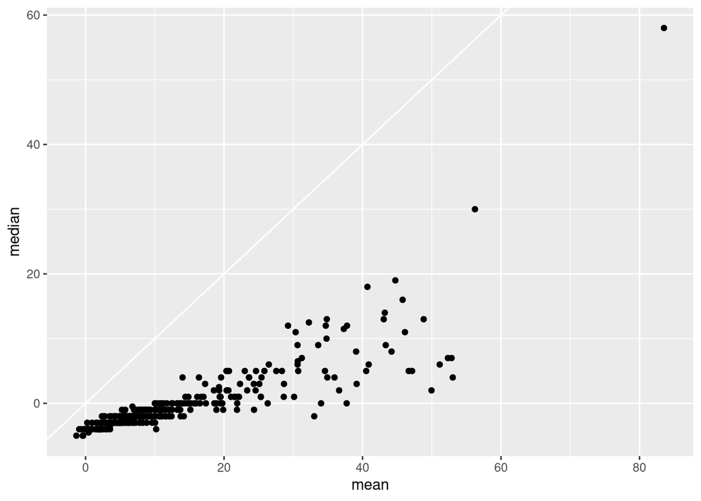

```r
flights |>
  group_by(year, month, day) |>
  summarize(
    mean = mean(dep_delay, na.rm = TRUE),
    median = median(dep_delay, na.rm = TRUE),
    n = n(),
    .groups = "drop"
  ) |>
  ggplot(aes(x = mean, y = median)) +
  geom_abline(slope = 1, intercept = 0, color = "white") +
  geom_point()
```

- There is no **mode** function in R; this is not useful in real-wold data and statisticians tend not to use this function.

### Minimum, maximum, and quantiles

Looking at the the 95% quantile of a data feature while ignoring the extreme 5% of cases:

```r
flights |>
  group_by(year, month, day) |>
  summarize(
    max = max(dep_delay, na.rm = TRUE),
    q95 = quantile(dep_delay, 0.95, na.rm = TRUE),
    .groups = "drop"
  )
```

```
## # A tibble: 365 × 5
##     year month   day   max   q95
##    <int> <int> <int> <dbl> <dbl>
##  1  2013     1     1   853  70.1
##  2  2013     1     2   379  85
##  3  2013     1     3   291  68
##  4  2013     1     4   288  60
##  5  2013     1     5   327  41
##  6  2013     1     6   202  51
##  7  2013     1     7   366  51.6
##  8  2013     1     8   188  35.3
##  9  2013     1     9  1301  27.2
## 10  2013     1    10  1126  31
## # ℹ 355 more rows
```

### Spread

- `IQR()` is basically `quantile(x, 0.75) - quantile(x, 0.25).

Exploring the curious case of EGE Airport using `IQR`:

```r
flights |>
  group_by(origin, dest) |>
  summarize(
    distance_iqr = IQR(distance),
    n = n(),
    .groups = "drop"
  ) |>
  filter(distance_iqr > 0)
```

```
## # A tibble: 2 × 4
##   origin dest  distance_iqr     n
##   <chr>  <chr>        <dbl> <int>
## 1 EWR    EGE              1   110
## 2 JFK    EGE              1   103
```

### Distributions

- Frequency plots of `dep_delay` for each day, for 365 days, overlaid, used to check if the distributions for subgroups resemble the whole:

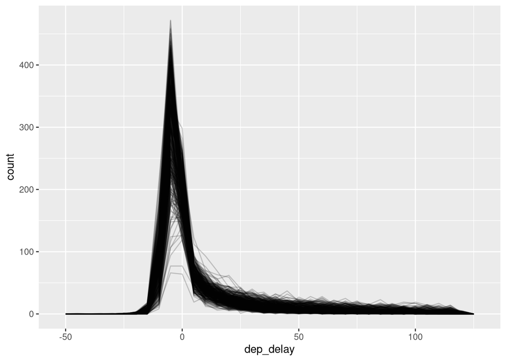

```r
flights |>
  filter(dep_delay < 120) |>
  ggplot(aes(x = dep_delay, group = interaction(day, month))) +
  geom_freqpoly(binwidth = 5, alpha = 1/5)
```

- Whenever creating numerical summaries, it is a good idea to include the number of observations in each group.

### Extracting values at nth position

- Example for extracting the `nth` value using position functions `first`, `last`, and `nth`:

```r
flights |>
  group_by(year, month, day) |>
  summarize(
    first_dep = first(dep_time, na_rm = TRUE),
    fifth_dep = nth(dep_time, 5, na_rm = TRUE),
    last_dep = last(dep_time, na_rm = TRUE)
  )
```

```
## # A tibble: 365 × 6
## # Groups:   year, month [12]
##     year month   day first_dep fifth_dep last_dep
##    <int> <int> <int>     <int>     <int>    <int>
##  1  2013     1     1       517       554     2356
##  2  2013     1     2        42       535     2354
##  3  2013     1     3        32       520     2349
##  4  2013     1     4        25       531     2358
##  5  2013     1     5        14       534     2357
##  6  2013     1     6        16       555     2355
##  7  2013     1     7        49       536     2359
##  8  2013     1     8       454       544     2351
##  9  2013     1     9         2       524     2252
## 10  2013     1    10         3       530     2320
## # ℹ 355 more rows
```

- Be careful when using `first`, `nth`, and `last` – the argument for removing `NA`s is `na_rm` and *not* `na.rm`.
- Extracting values at positions using filtering on ranks:

```r
flights |>
  group_by(year, month, day) |>
  mutate(r = min_rank(sched_dep_time)) |>
  filter(r %in% c(1, max(r)))
```

```
## # A tibble: 1,195 × 20
## # Groups:   year, month, day [365]
##     year month   day dep_time sched_dep_time dep_delay arr_time sched_arr_time
##    <int> <int> <int>    <int>          <int>     <dbl>    <int>          <int>
##  1  2013     1     1      517            515         2      830            819
##  2  2013     1     1     2353           2359        -6      425            445
##  3  2013     1     1     2353           2359        -6      418            442
##  4  2013     1     1     2356           2359        -3      425            437
##  5  2013     1     2       42           2359        43      518            442
##  6  2013     1     2      458            500        -2      703            650
##  7  2013     1     2     2351           2359        -8      427            445
##  8  2013     1     2     2354           2359        -5      413            437
##  9  2013     1     3       32           2359        33      504            442
## 10  2013     1     3      235           2359       156      700            437
## # ℹ 1,185 more rows
## # ℹ 12 more variables: arr_delay <dbl>, carrier <chr>, flight <int>,
## #   tailnum <chr>, origin <chr>, dest <chr>, air_time <dbl>, distance <dbl>,
## #   hour <dbl>, minute <dbl>, time_hour <dttm>, r <int>
```

### Summary functions using `mutate()`

- Useful when a standardized summary function is preferred.

Examples of `mutate` commands for summarizing data:  
- `x / sum(x)` for getting the proportion of total.  
- `(x - mean(x)) / sd(x)` for calculating the z-score (standardized to have a mean of 0 and sd of 1).  
- `(x - min(x)) / (max(x) - min(x))` for standardizing the data range to [0, 1].  
- `x / first(x)` for generating an index based on the first observation.